# Difference-in-Difference

Bradley McKenzie

June 2025

## Purpose

This script is based on DiD code from a course within our Master in Computational Social Sciences taught by Patrick Kraft.

## Call existing scripts to get data and code.

First we call the exisitng models so we have our cleaned dataset. This is the nested process from these scripts: - Dataframe creation_ESS.Rmd -> load data - Univariate analysis.Rmd -> create weighted averages for each country in each round for each trust measure - Multivariate analysis.Rmd -> cleans the demographic variables and models weighted averages within groups across R6-R11.

The primary first step is to create an account on ESS, download data and update the file location that calls your underlying dataset within the Dataframe creation script.

#### Additional libraries:

```r
library(broom)
library(estimatr)
library(multiwayvcov)
library(plm)
library(lmtest)
library(fixest)
library(modelsummary)
```

### Review parallel trends assumption.

#### Visual inspection.

This recreates the plots from “Univariate analysis.Rmd” to show the parallel trends assumption is satisfied:

##### The pre-Referendum period

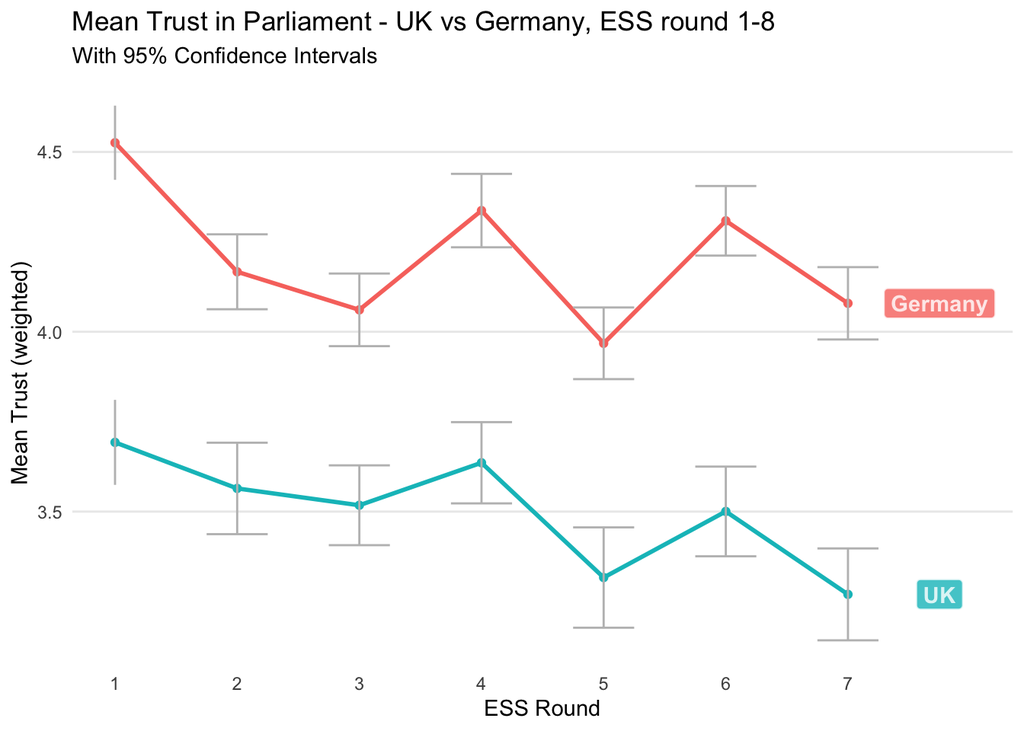

```r
### plotting just the pre-Referendum periods
trust_summaries_df |>
  # limit data
  filter(trust_variable == "trust_europ",
         cntry %in% c("GB", "DE"),
         essround <8) |>
  #clean names for plotting
  mutate(cntry = ifelse(cntry == "GB", "UK", "Germany"),
         trust_variable = ifelse(trust_variable == "trust_europ", "Trust in European Parliament", trust_variable)) |>
  # plot
ggplot(aes(x = essround, y = wt_avg_mean,
           group = cntry, colour = cntry)) +
  geom_line(size = 1) +  # Line for the trend
  geom_point(size = 1.5) +  # Points for each mean
  geom_errorbar(aes(ymin = ci_l, ymax = ci_u),  # Error bars using CI bounds
                width = 0.5,  # Width of the error bar caps
                color = "gray") +
  labs(title = "Mean Trust in Parliament - UK vs Germany, ESS round 1-8",
       subtitle = "With 95% Confidence Intervals",
       x = "ESS Round",
       y = "Mean Trust (weighted)") +
  theme_minimal()+

  # add extra labels to see each item
  geom_label_repel(
    data = . %>% group_by(trust_variable) %>% filter(essround == max(essround)),
    aes(label = cntry, fill = cntry),
    color = "white",
    fontface = "bold",
    alpha = 0.8,
    label.size = 0.5,
    show.legend = FALSE,
    box.padding = unit(0.5, "lines"),
    point.padding = unit(0.5, "lines"),
    segment.colour = NA,
    direction = "y",
    nudge_x = 0.75,
    min.segment.length = 0)+
    # set limits
  scale_x_continuous(breaks = seq(1,7,1),
                     limits = c(min(trust_summaries_df$essround),8)) +
  # add referendum line
  # geom_vline(xintercept = 7.7, color = "orange", size = 1.5, alpha = 0.5)+
  # annotate(geom="text", x = 7.4, y =4.5, label = "Referendum",
  #            angle = 90, color = "orange")+
  theme(legend.position = "none",
        panel.grid.major.x = element_blank(), # Remove vertical grid lines
        panel.grid.minor.x = element_blank(),
        panel.grid.minor.y = element_blank()
  )
```

2. Plotting for all available data - R1-R11.

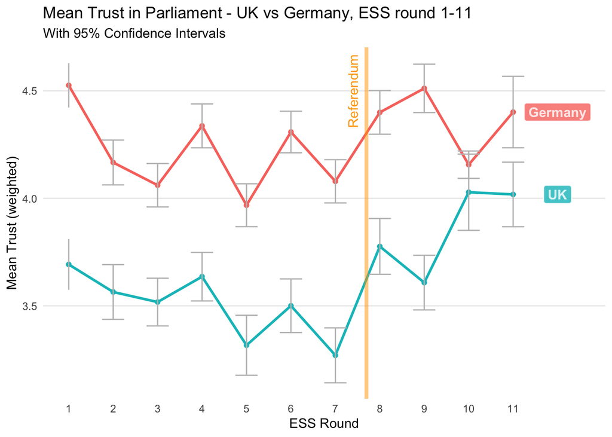

```r
### plotting just the pre-Referendum periods
trust_summaries_df |>
  # limit data
  filter(trust_variable == "trust_europ",
         cntry %in% c("GB", "DE")) |>
  #clean names for plotting
  mutate(cntry = ifelse(cntry == "GB", "UK", "Germany"),
         trust_variable = ifelse(trust_variable == "trust_europ", "Trust in European Parliament", trust_variable)) |>
  # plot
ggplot(aes(x = essround, y = wt_avg_mean,
           group = cntry, colour = cntry)) +
  geom_line(size = 1) +  # Line for the trend
  geom_point(size = 1.5) +  # Points for each mean
  geom_errorbar(aes(ymin = ci_l, ymax = ci_u),  # Error bars using CI bounds
                width = 0.5,  # Width of the error bar caps
                color = "gray") +
  labs(title = "Mean Trust in Parliament - UK vs Germany, ESS round 1-11",
       subtitle = "With 95% Confidence Intervals",
       x = "ESS Round",
       y = "Mean Trust (weighted)") +
  theme_minimal()+

  # add extra labels to see each item
  geom_label_repel(
    data = . %>% group_by(trust_variable) %>% filter(essround == max(essround)),
    aes(label = cntry, fill = cntry),
    color = "white",
    fontface = "bold",
    alpha = 0.8,
    label.size = 0.5,
    show.legend = FALSE,
    box.padding = unit(0.5, "lines"),
    point.padding = unit(0.5, "lines"),
    segment.colour = NA,
    direction = "y",
    nudge_x = 1,
    min.segment.length = 0)+
    # set limits
  scale_x_continuous(breaks = seq(1,11,1),
                     limits = c(min(trust_summaries_df$essround),max(trust_summaries_df$essround)+1.5)) +
  # add referendum line
  geom_vline(xintercept = 7.7, color = "orange", size = 1.5, alpha = 0.5)+
  annotate(geom="text", x = 7.4, y =4.5, label = "Referendum",
             angle = 90, color = "orange")+
  theme(legend.position = "none",
        panel.grid.major.x = element_blank(), # Remove vertical grid lines
        panel.grid.minor.x = element_blank(),
        panel.grid.minor.y = element_blank()
  )
```

## Run crude DiD model

We calculate the pre and post-treatment means for the control (Germany) and treatment (UK). We have these mean values in each round created in our trust_summaries dataframe:

```r
# create smaller dataset to work with.
did_trust_eu_crude <- trust_summaries_df |>
  filter(cntry %in% c("GB", "DE"),
         trust_variable == "trust_europ") |>
  mutate(cntry = ifelse(cntry == "GB", "UK", "Germany"),
         trust_variable = ifelse(trust_variable == "trust_europ", "Trust in European Parliament", trust_variable))

print(did_trust_eu_crude)
```

```
## # A tibble: 22 × 6
##    essround cntry   trust_variable               wt_avg_mean  ci_l  ci_u
##       <dbl> <chr>   <chr>                              <dbl> <dbl> <dbl>
##  1        1 Germany Trust in European Parliament        4.53  4.42  4.63
##  2        1 UK      Trust in European Parliament        3.69  3.57  3.81
##  3        2 Germany Trust in European Parliament        4.17  4.06  4.27
##  4        2 UK      Trust in European Parliament        3.56  3.44  3.69
##  5        3 Germany Trust in European Parliament        4.06  3.96  4.16
##  6        3 UK      Trust in European Parliament        3.52  3.41  3.63
##  7        4 Germany Trust in European Parliament        4.34  4.23  4.44
##  8        4 UK      Trust in European Parliament        3.64  3.52  3.75
##  9        5 Germany Trust in European Parliament        3.97  3.87  4.07
## 10        5 UK      Trust in European Parliament        3.32  3.18  3.46
## # ℹ 12 more rows
```

Now calculate our per and post treatment measures: The referendum was 23 June 2016. The R8 fieldwork happened in September 2016 - January 2017. This is our post-period.  
The R7 fieldwork happened in September 2014 - January 2015. This is our pre-period.

```r
# calc weighted values
pre_treat <- did_trust_eu_crude |> filter(essround == 7, cntry == "UK") |> pull(wt_avg_mean)
post_treat <- did_trust_eu_crude |> filter(essround == 8, cntry == "UK") |> pull(wt_avg_mean)
pre_control <- did_trust_eu_crude |> filter(essround == 7, cntry == "Germany") |> pull(wt_avg_mean)
post_control <- did_trust_eu_crude |> filter(essround == 8, cntry == "Germany") |> pull(wt_avg_mean)

# calc crude DiD score.
did <- (post_treat-pre_treat)-(post_control-pre_control)
did
```

```
## [1] 0.1858795
```

```r
# print results
glue("In the pre-Referndum period, the UK had a weighted mean trust in the EU parliament of {round(pre_treat,2)}, which increased to {round(post_treat,2)} in R8 of the ESS post-Referndum (+{round(post_treat-pre_treat,2)}).\n
     Germany's EU Parliament trust increased from {round(pre_control,2)} in R7 to {round(post_control,2)} in R8 (+{round(post_control-pre_control,2)}).\n
     The did score (post_treat-pre_treat)-(post_control-pre_control) = {round(did,3)}")
```

```
## In the pre-Referndum period, the UK had a weighted mean trust in the EU parliament of 3.27, which increased to 3.78 in R8 of the ESS post-Referndum (+0.51).
##
## Germany's EU Parliament trust increased from 4.08 in R7 to 4.4 in R8 (+0.32).
##
## The did score (post_treat-pre_treat)-(post_control-pre_control) = 0.186
```

This means that the average trust in the EU parliament increased 0.18 points out of 10 in teh UK compared to Germany in this period. We now test whether this is significant and include covariates.

Test with survey mean package:

```r
simple_design_did <- ess_clean |>
  as_survey_design(weights = anweight, ids = 1) |>
  filter(cntry %in% c("GB", "DE"))


simple_design <- svydesign(ids = ~1, weights = ~anweight, data = ess_clean)

results_srvyr <- simple_design_did |>
  filter(!is.na(trust_europ)) |>  # Important: filter NA values before grouping if they affect your groups
  group_by(cntry, essround) |>
  summarize(
    mean_trust_europ = survey_mean(trust_europ, na.rm = TRUE),
    n_observations = unweighted(n()) # To get the unweighted count in each group
  )



results_srvyr |> arrange(desc(essround)) |> group_by(essround) |> summarise(max = max(mean_trust_europ),
                                                                            min = min(mean_trust_europ),
                                                                            diff = max-min)
```

| essround | max | min | diff |
| --- | --- | --- | --- |
| 6 | 4.308537 | 3.500438 | 0.8080990 |
| 7 | 4.079133 | 3.269846 | 0.8092873 |
| 8 | 4.399756 | 3.776348 | 0.6234077 |
| 9 | 4.511461 | 3.608064 | 0.9033970 |
| 10 | 4.156465 | 4.028468 | 0.1279974 |
| 11 | 4.401195 | 4.018203 | 0.3829924 |

Create dataframes to measure the effect at various stages:

```r
# create df for just Germany and Uk in R7+ R8
ess_did_w7w8 <- ess_clean |>
  filter(cntry %in% c("GB", "DE"),
         essround %in% c(7,8)) |>
  mutate(PostPeriod = ifelse(essround == 8, 1,0))

# create df for R7+R9
ess_did_w7w9 <- ess_clean |>
  filter(cntry %in% c("GB", "DE"),
         essround %in% c(7,9)) |>
  mutate(PostPeriod = ifelse(essround == 9, 1,0))

# create df for R6+R7 (pre-period robustness check)
ess_did_w6w7 <- ess_clean |>
  filter(cntry %in% c("GB", "DE"),
         essround %in% c(6,7)) |>
  mutate(PostPeriod = ifelse(essround == 7, 1,0))
```

### DiD crude between R7 and R8

Now we estimate for the immediate effect:

```r
# we use all 3 datasets to see the controls
m_w7w8 <- lm_robust(trust_europ ~ cntry*PostPeriod,
                   data = ess_did_w7w8)
summary(m_w7w8) # results below:
```

```
##
## Call:
## lm_robust(formula = trust_europ ~ cntry * PostPeriod, data = ess_did_w7w8)
##
## Standard error type:  HC2
##
## Coefficients:
##                    Estimate Std. Error t value  Pr(>|t|) CI Lower CI Upper   DF
## (Intercept)          3.9856    0.04505  88.468 0.000e+00  3.89731   4.0739 9626
## cntryGB             -0.9055    0.06998 -12.940 5.513e-38 -1.04272  -0.7684 9626
## PostPeriod           0.3607    0.06438   5.602 2.176e-08  0.23448   0.4869 9626
## cntryGB:PostPeriod   0.1097    0.10108   1.085 2.777e-01 -0.08842   0.3079 9626
##
## Multiple R-squared:  0.03591 ,   Adjusted R-squared:  0.03561
## F-statistic: 119.3 on 3 and 9626 DF,  p-value: < 2.2e-16
```

This is not significant, HOWEVER - We see a different score in our interaction value than the above as there aren’t weighted. Calc again with weighted values:

From both of these calculations we get our true effect post-Referendum (in the interaction term (cntryGB:PostPeriod = 0.18588)) and also are able to apply the weights effectively.

```r
# calc weighted values.
m_w7w8_wt <- lm_robust(trust_europ ~ cntry*PostPeriod,
                   data = ess_did_w7w8,
                   weights = anweight)
summary(m_w7w8_wt) # results below:
```

```
##
## Call:
## lm_robust(formula = trust_europ ~ cntry * PostPeriod, data = ess_did_w7w8,
##     weights = anweight)
##
## Weighted, Standard error type:  HC2
##
## Coefficients:
##                    Estimate Std. Error t value  Pr(>|t|) CI Lower CI Upper   DF
## (Intercept)          4.0791    0.05132  79.490 0.000e+00  3.97854   4.1797 9626
## cntryGB             -0.8093    0.08299  -9.752 2.292e-22 -0.97196  -0.6466 9626
## PostPeriod           0.3206    0.07295   4.395 1.120e-05  0.17762   0.4636 9626
## cntryGB:PostPeriod   0.1859    0.11818   1.573 1.158e-01 -0.04579   0.4175 9626
##
## Multiple R-squared:  0.02721 ,   Adjusted R-squared:  0.0269
## F-statistic: 65.65 on 3 and 9626 DF,  p-value: < 2.2e-16
```

```r
modelsummary(m_w7w8_wt)
```

|  | (1) |
| --- | --- |
| (Intercept) | 4.079 |
|  | (0.051) |
| cntryGB | -0.809 |
|  | (0.083) |
| PostPeriod | 0.321 |
|  | (0.073) |
| cntryGB × PostPeriod | 0.186 |
|  | (0.118) |
| Num.Obs. | 9630 |
| R2 | 0.027 |
| R2 Adj. | 0.027 |
| AIC | 45847.6 |
| BIC | 45883.5 |
| RMSE | 2.44 |

```r
## or weighted model with the svyglm package -
simple_design_w7w8 <- ess_did_w7w8 |>
  as_survey_design(weights = anweight, ids = 1)

m_w7w8_wt2 <- svyglm(trust_europ ~ cntry * PostPeriod,
                            design = simple_design_w7w8,
                            family = gaussian(link = "identity")) # For OLS, specify gaussian family
summary(m_w7w8_wt2)
```

```
##
## Call:
## svyglm(formula = trust_europ ~ cntry * PostPeriod, design = simple_design_w7w8,
##     family = gaussian(link = "identity"))
##
## Survey design:
## Called via srvyr
##
## Coefficients:
##                    Estimate Std. Error t value Pr(>|t|)
## (Intercept)         4.07913    0.05130  79.508  < 2e-16 ***
## cntryGB            -0.80929    0.08296  -9.755  < 2e-16 ***
## PostPeriod          0.32062    0.07294   4.396 1.11e-05 ***
## cntryGB:PostPeriod  0.18588    0.11814   1.573    0.116
## ---
## Signif. codes:  0 '***' 0.001 '**' 0.01 '*' 0.05 '.' 0.1 ' ' 1
##
## (Dispersion parameter for gaussian family taken to be 5.917873)
##
## Number of Fisher Scoring iterations: 2
```

We see that it is STILL NOT statistically significant at the 5% level. There is an increase but it’s not statistically signfiicant.

#### Testing ongoing effect - comparing R7 to R9

Test the effect for R7 and R9 to see if it changes. Use weighted values for accuracy.

```r
# calc weighted values.
m_w7w9_wt <- lm_robust(trust_europ ~ cntry*PostPeriod,
                   data = ess_did_w7w9,
                   weights = anweight)
#print results:
summary(m_w7w9_wt)
```

```
##
## Call:
## lm_robust(formula = trust_europ ~ cntry * PostPeriod, data = ess_did_w7w9,
##     weights = anweight)
##
## Weighted, Standard error type:  HC2
##
## Coefficients:
##                    Estimate Std. Error t value  Pr(>|t|) CI Lower CI Upper   DF
## (Intercept)         4.07913    0.05132 79.4902 0.000e+00   3.9785   4.1797 9393
## cntryGB            -0.80929    0.08299 -9.7521 2.306e-22  -0.9720  -0.6466 9393
## PostPeriod          0.43233    0.07703  5.6128 2.047e-08   0.2813   0.5833 9393
## cntryGB:PostPeriod -0.09411    0.11996 -0.7845 4.328e-01  -0.3293   0.1410 9393
##
## Multiple R-squared:  0.0343 ,    Adjusted R-squared:  0.03399
## F-statistic: 79.34 on 3 and 9393 DF,  p-value: < 2.2e-16
```

We see that between period between Round 7 and Round 9, we have a negative effect. It is NOT statistically significant with a t-value of -0.7845 and a p-value ~= 0.43. So we don’t observe an ongoing trend here.

#### Testing pre-treatment effect - comparing R6 to R7

```r
# calc weighted values.
m_w6w7_wt <- lm_robust(trust_europ ~ cntry*PostPeriod,
                   data = ess_did_w6w7,
                   weights = anweight)
#print results:
summary(m_w6w7_wt)
```

```
##
## Call:
## lm_robust(formula = trust_europ ~ cntry * PostPeriod, data = ess_did_w6w7,
##     weights = anweight)
##
## Weighted, Standard error type:  HC2
##
## Coefficients:
##                     Estimate Std. Error   t value  Pr(>|t|) CI Lower CI Upper
## (Intercept)         4.308537    0.04937  87.26800 0.000e+00   4.2118  4.40531
## cntryGB            -0.808099    0.08055 -10.03234 1.431e-23  -0.9660 -0.65021
## PostPeriod         -0.229404    0.07121  -3.22151 1.279e-03  -0.3690 -0.08982
## cntryGB:PostPeriod -0.001188    0.11565  -0.01027 9.918e-01  -0.2279  0.22551
##                      DF
## (Intercept)        9724
## cntryGB            9724
## PostPeriod         9724
## cntryGB:PostPeriod 9724
##
## Multiple R-squared:  0.02921 ,   Adjusted R-squared:  0.02891
## F-statistic: 71.11 on 3 and 9724 DF,  p-value: < 2.2e-16
```

We see there is no statistically significant difference between R6 and R7 in the lead up between Germany and the UK. The analysis shows that the trends were similar in trust to the EU. This could be due to the impact of the refugee crisis Germany was experiencing around R6 and broader collapse in EU trust for the Uk with Brexit (including the impact of coverage of the refugee crisis).

In fact, there is also no difference in effect between Germany and Uk between R6 and R7 with both decreasing to their R7 low. they both dropped around 0.23 points from R6 but there was a negligable difference between them otherwise.

Thus we cannot see measurable differences in the crude DiD between Germany and the UK.

#### Longer time period crude model

Comparing all waves to the base period, (R6). Treat time as a factor rather than modelling a linear trend (which it would be if we kept it numeric)

```r
summary(lm_robust(formula = trust_europ ~ cntry * factor(essround),
                  data = filter(ess_clean,
                                cntry %in% c("GB", "DE")),
                  weights = anweight))
```

```
##
## Call:
## lm_robust(formula = trust_europ ~ cntry * factor(essround), data = filter(ess_clean,
##     cntry %in% c("GB", "DE")), weights = anweight)
##
## Weighted, Standard error type:  HC2
##
## Coefficients:
##                             Estimate Std. Error   t value  Pr(>|t|) CI Lower
## (Intercept)                 4.308537    0.04937  87.26800 0.000e+00  4.21177
## cntryGB                    -0.808099    0.08055 -10.03234 1.191e-23 -0.96598
## factor(essround)7          -0.229404    0.07121  -3.22151 1.276e-03 -0.36898
## factor(essround)8           0.091219    0.07160   1.27402 2.027e-01 -0.04912
## factor(essround)9           0.202924    0.07574   2.67910 7.386e-03  0.05446
## factor(essround)10         -0.152072    0.05906  -2.57477 1.004e-02 -0.26784
## factor(essround)11          0.092658    0.09813   0.94425 3.451e-01 -0.09968
## cntryGB:factor(essround)7  -0.001188    0.11565  -0.01027 9.918e-01 -0.22787
## cntryGB:factor(essround)8   0.184691    0.11649   1.58551 1.129e-01 -0.04363
## cntryGB:factor(essround)9  -0.095298    0.11829  -0.80564 4.205e-01 -0.32715
## cntryGB:factor(essround)10  0.680102    0.12542   5.42246 5.921e-08  0.43427
## cntryGB:factor(essround)11  0.425107    0.13984   3.04001 2.368e-03  0.15102
##                            CI Upper    DF
## (Intercept)                 4.40531 32063
## cntryGB                    -0.65022 32063
## factor(essround)7          -0.08983 32063
## factor(essround)8           0.23156 32063
## factor(essround)9           0.35138 32063
## factor(essround)10         -0.03631 32063
## factor(essround)11          0.28500 32063
## cntryGB:factor(essround)7   0.22549 32063
## cntryGB:factor(essround)8   0.41301 32063
## cntryGB:factor(essround)9   0.13655 32063
## cntryGB:factor(essround)10  0.92594 32063
## cntryGB:factor(essround)11  0.69919 32063
##
## Multiple R-squared:  0.02117 ,   Adjusted R-squared:  0.02083
## F-statistic:  40.6 on 11 and 32063 DF,  p-value: < 2.2e-16
```

We see that compared to Round 6, it appears that only Round 10 and Round 11 were significant.

We do not perform additional measurements with fixed effects as we don’t have longitudinal data to check “within” group changes.

### Testing DiD with covariates - Robustness check

Include covariates that are significant after the lasso adjustment :

```r
m_r8_gaus <- glm(trust_europ ~ gender + age_rec + educ_level + income_group + income_stress + ethnic_minority + area_type + health_disability + left_right + polintr_binary + life_sat + econ_sat + immig_support + daily_netuse + country_attach + post_polonline,
      data = filter(gb_clean, essround == 8),
      family = "gaussian")

summary(m_r8_gaus)
```

```
##
## Call:
## glm(formula = trust_europ ~ gender + age_rec + educ_level + income_group +
##     income_stress + ethnic_minority + area_type + health_disability +
##     left_right + polintr_binary + life_sat + econ_sat + immig_support +
##     daily_netuse + country_attach + post_polonline, family = "gaussian",
##     data = filter(gb_clean, essround == 8))
##
## Coefficients:
##                                               Estimate Std. Error t value
## (Intercept)                                    6.41677    0.54734  11.724
## genderFemale                                   0.30907    0.11500   2.688
## age_rec20-29                                  -0.69926    0.43631  -1.603
## age_rec30-44                                  -1.01151    0.42040  -2.406
## age_rec45-64                                  -1.12370    0.42258  -2.659
## age_rec>=65                                   -1.72195    0.43495  -3.959
## educ_levelUpper secondary                     -0.15992    0.16376  -0.977
## educ_levelTertiary                             0.35299    0.15399   2.292
## income_groupLow (Decile <4)                    0.26081    0.18341   1.422
## income_groupModerate (Decile 4-7)              0.04106    0.14932   0.275
## income_stressCoping on present income         -0.11511    0.13070  -0.881
## income_stressDifficult on present income       0.11956    0.22913   0.522
## income_stressVery difficult on present income -0.23375    0.37763  -0.619
## ethnic_minorityNo                              0.05581    0.21882   0.255
## area_typeSuburbs or outskirts of big city     -0.31792    0.23464  -1.355
## area_typeTown or small city                   -0.53204    0.21630  -2.460
## area_typeCountry                              -0.52928    0.22896  -2.312
## health_disabilityYes                          -0.19881    0.13747  -1.446
## left_rightModerate (4-6)                      -0.37644    0.15129  -2.488
## left_rightRight (7-10)                        -0.89929    0.20019  -4.492
## polintr_binaryYes                              0.18801    0.13161   1.429
## life_satModerate                              -0.31469    0.15663  -2.009
## life_satLow                                   -0.92329    0.28048  -3.292
## econ_satModerate                              -0.10701    0.14049  -0.762
## econ_satLow                                   -0.92315    0.17748  -5.201
## immig_supportModerate                         -0.92868    0.13267  -7.000
## immig_supportLow                              -2.08230    0.17433 -11.944
## daily_netuseYes                               -0.12818    0.14169  -0.905
## country_attachModerate                         0.08612    0.13962   0.617
## country_attachLow                             -0.19412    0.20307  -0.956
```

[output cut: 29 more lines]

```
## daily_netuseYes                                0.36580
## country_attachModerate                         0.53745
## country_attachLow                              0.33928
## post_polonlineYes                              0.73146
## ---
## Signif. codes:  0 '***' 0.001 '**' 0.01 '*' 0.05 '.' 0.1 ' ' 1
##
## (Dispersion parameter for gaussian family taken to be 4.387358)
##
##     Null deviance: 8081.2  on 1420  degrees of freedom
## Residual deviance: 6098.4  on 1390  degrees of freedom
##   (538 observations deleted due to missingness)
## AIC: 6166.6
##
## Number of Fisher Scoring iterations: 2
```

Let’s add covariates. Why add them? what purpose do they serve?

- We at least control for the known observed confounding variables -> this is an additional robustness check.

```r
ess_clean <- ess_clean |> mutate(post_polonline = factor(case_when(post_polonline == 2 ~ "No",
                                                      post_polonline == 1 ~ "Yes",
                                                      TRUE ~ NA))
)
```

```r
m_w7w8_weighted_did_covars <- svyglm(
  trust_europ ~ cntry*PostPeriod + # DiD terms
        # incl all demog variables to see
                gender + age_rec + educ_level + income_group + income_stress +
                ethnic_minority + area_type + health_disability + left_right +
                polintr_binary + life_sat + econ_sat + immig_support,
               ##  daily_netuse + country_attach + post_polonline, ## DON'T INCLUDE R8 Only variables
  design = simple_design_w7w8,
  family = gaussian(link = "identity") # For OLS regression
)

summary(m_w7w8_weighted_did_covars)
```

```
##
## Call:
## svyglm(formula = trust_europ ~ cntry * PostPeriod + gender +
##     age_rec + educ_level + income_group + income_stress + ethnic_minority +
##     area_type + health_disability + left_right + polintr_binary +
##     life_sat + econ_sat + immig_support, design = simple_design_w7w8,
##     family = gaussian(link = "identity"))
##
## Survey design:
## Called via srvyr
##
## Coefficients:
##                                                 Estimate Std. Error t value
## (Intercept)                                    6.9973484  0.2088869  33.498
## cntryGB                                       -0.4974418  0.0866900  -5.738
## PostPeriod                                     0.2443997  0.0708164   3.451
## genderFemale                                   0.4139419  0.0561147   7.377
## age_rec20-29                                  -0.8770027  0.1610089  -5.447
## age_rec30-44                                  -1.4629533  0.1522015  -9.612
## age_rec45-64                                  -1.7443164  0.1491952 -11.692
## age_rec>=65                                   -1.9224794  0.1558546 -12.335
## educ_levelUpper secondary                     -0.2294590  0.0914022  -2.510
## educ_levelTertiary                             0.0445346  0.0921737   0.483
## income_groupLow (Decile <4)                    0.0035366  0.0862997   0.041
## income_groupModerate (Decile 4-7)             -0.0897841  0.0676293  -1.328
## income_stressCoping on present income          0.0001937  0.0636934   0.003
## income_stressDifficult on present income       0.0581908  0.1226277   0.475
## income_stressVery difficult on present income -0.0248535  0.2239597  -0.111
## ethnic_minorityNo                             -0.3266006  0.1277894  -2.556
## area_typeSuburbs or outskirts of big city     -0.0643317  0.1083010  -0.594
## area_typeTown or small city                   -0.1458436  0.0954605  -1.528
## area_typeCountry                              -0.1549495  0.0974592  -1.590
## health_disabilityYes                          -0.0161787  0.0661415  -0.245
## left_rightModerate (4-6)                      -0.0206409  0.0677241  -0.305
## left_rightRight (7-10)                        -0.1400002  0.0958453  -1.461
## polintr_binaryYes                              0.1211314  0.0633970   1.911
## life_satModerate                              -0.3801854  0.0787080  -4.830
## life_satLow                                   -0.6132899  0.1456463  -4.211
## econ_satModerate                              -0.5186984  0.0670129  -7.740
## econ_satLow                                   -1.1534272  0.0934451 -12.343
```

[output cut: 25 more lines]

```
## left_rightRight (7-10)                        0.144141
## polintr_binaryYes                             0.056082 .
## life_satModerate                              1.39e-06 ***
## life_satLow                                   2.57e-05 ***
## econ_satModerate                              1.12e-14 ***
## econ_satLow                                    < 2e-16 ***
## immig_supportModerate                          < 2e-16 ***
## immig_supportLow                               < 2e-16 ***
## cntryGB:PostPeriod                            0.942906
## ---
## Signif. codes:  0 '***' 0.001 '**' 0.01 '*' 0.05 '.' 0.1 ' ' 1
##
## (Dispersion parameter for gaussian family taken to be 4.409745)
##
## Number of Fisher Scoring iterations: 2
```

We see the interaction term is still not significant in estimating trust in europe.